# Super-resolution of Images using CNNs

### Load the HDF5 model for Visualization of Results

```python
import keras.backend as K

def PSNR(y_true, y_pred):
    """
    PSNR is Peek Signal to Noise Ratio, which is similar to mean squared error.
    It can be calculated as
    PSNR = 20 * log10(MAXp) - 10 * log10(MSE)

    However, since we are scaling our input, MAXp = 1. Therefore 20 * log10(1) = 0.
    Thus we remove that component completely and only compute the remaining MSE component.
    """
    return -10. * K.log(K.mean(K.square(y_pred - y_true))) / K.log(10.)
```

```python
from keras.models import load_model
model = load_model('research_paper_based_model.h5', custom_objects={"PSNR": PSNR})
```

```python
from DataGenerator import generate_training_dataset, read_training_dataset
```

Generate a sample of data for visualization from the training dataset T91 images.

```python
# Generating a few images for visualization
images_folder = '../T91/'
train_images=generate_training_dataset(images_folder, 25, 33, 33, 'T91_images')
```

```
0 images converted
10 images converted
20 images converted
Total 485 images created.
```

```python
import math
import numpy as np
import pandas as pd
import cv2
import matplotlib.pyplot as plt
# %matplotlib inline
```

```python
def get_interpolated_images(train_images, scale_percent):

    interpolated_images=np.zeros_like(train_images)

    for i in range(train_images.shape[0]):

        img = train_images[i]

        scale_percent = scale_percent # percent of original size
        width = int(img.shape[1] * scale_percent / 100)
        height = int(img.shape[0] * scale_percent / 100)
        dim = (width, height)

        # Adding Gaussian Blur to the high resolution image
        img = cv2.GaussianBlur(img, (0, 0), 1, 1)

        low_resolution_img = cv2.resize(img, dim, interpolation = cv2.INTER_AREA)

        width = int(img.shape[1])
        height = int(img.shape[0])
        dim = (width, height)

        # Bicubic interpolation preprocessing step
        interpolated_img = cv2.resize(low_resolution_img, dim, interpolation = cv2.INTER_CUBIC)

        interpolated_images[i]=interpolated_img

    return interpolated_images
```

```python
interpolated_images = get_interpolated_images(train_images, 33.33)
```

```python
print(interpolated_images.shape)
print(train_images.shape)
```

```
(485, 33, 33, 3)
(485, 33, 33, 3)
```

```python
# PSNR Metric Evaluation
def psnr(img1, img2, max_pixel):
    mse = np.mean( (img1 - img2) ** 2 )
    if mse == 0:
        return -1
    PIXEL_MAX = max_pixel
    return 20 * math.log10(PIXEL_MAX / math.sqrt(mse))
```

### Results Visualization

Visualize the bicubic interpolated images and the SRCNN improvement over those images by placing them side-by-side.

[output not shown]

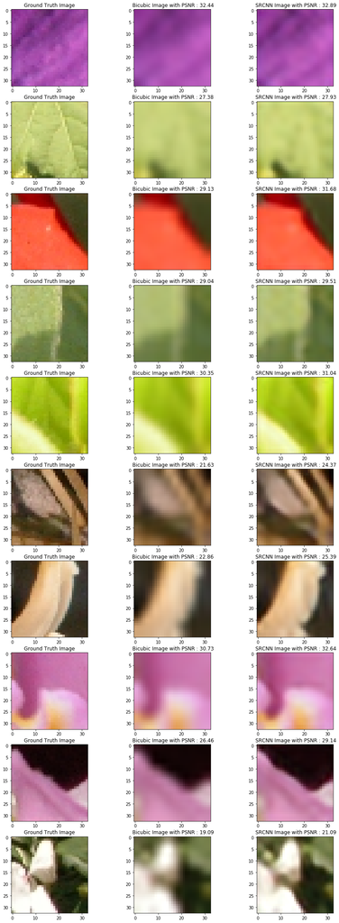

```python
plt.figure(figsize=(15,40))

for i in range(10):

    image_num = i*40

    bicubic_image = interpolated_images[image_num]
    actual_image = train_images[image_num]
    predicted_image = model.predict(np.expand_dims(bicubic_image,axis=0))[0]

    plt.subplot(10,3,i*3+1)
    plt.imshow(actual_image)
    plt.title(" Ground Truth Image ")

    plt.subplot(10,3,i*3+2)
    plt.imshow(bicubic_image)
    plt.title(" Bicubic Image with PSNR : "+ str(round(psnr(bicubic_image, actual_image, 1),2)))

    plt.subplot(10,3,i*3+3)
    plt.imshow(predicted_image)
    plt.title(" SRCNN Image with PSNR : "+ str(round(psnr(predicted_image, actual_image, 1),2)))
```

### Conclusion

In most of the images, we can observe from the PSNR values that our SRCNN model has brought an improvement in the image over the bicubic interpolation step. The purpose of this exercise was to prove that the SRCNN model is a feasible and useful process to upscale the images and aid in the process of super-resolution. In the next part of the project, I intend to use this concept, train a better model and extend this concept of SRCNN to handle large images by performing super-resolution on patches of the image. Do check out the second half of this project in the github repository.